# [experiments-ceus]Multinomial logistic regression model for modeling user interest

Thursday, May 21, 2015

This document is in line with the first revision for CEUS paper. The paper is about using multinomial logistic regression models to model/predict user interest (venue categoty) in LBSN, more specifically, Foursquare.

The experimantal datasets are crawled from three cities in USA, namely Chicago, Los Angeles and New York City. The reason for choosing these three study sites is because users in these cities have high level of activity in both Foursquare and Twitter. (Foursquare only makes the check-ins that are published via Twitter public.)

#### 1. load the data

First, we load the data. The first several rows for each city is shown in the following to demonstrate the data structure.

```
## [1] "Chicago"
```

```
##           gid user_id                 venue_id   lat    lon
## 143728 330387     213 4a5a77a4f964a52062ba1fe3 41.98 -87.90
## 145388 345968     213 4a5a77a4f964a52062ba1fe3 41.98 -87.90
## 90185  208505     306 52eeca25498e7e42997774eb 41.89 -87.66
## 93642  216826     306 4b58b51ff964a520b16628e3 41.89 -87.66
## 93814  218762     306 52eeca25498e7e42997774eb 41.89 -87.66
## 136036 303635     306 4a5a77a4f964a52062ba1fe3 41.98 -87.90
##                     localtime                     cate_l1
## 143728 2014-05-07 05:05:09-05          Travel & Transport
## 145388 2014-05-08 10:27:00-05          Travel & Transport
## 90185  2014-04-02 09:44:09-05 Professional & Other Places
## 93642  2014-04-04 16:18:40-05                        Food
## 93814  2014-04-04 17:48:21-05 Professional & Other Places
## 136036 2014-05-02 10:57:05-05          Travel & Transport
##                   cate_l2   ZIP                last.cate_l1
## 143728            Airport 60666                        <NA>
## 145388            Airport 60666          Travel & Transport
## 90185         Event Space 60642                        <NA>
## 93642  Italian Restaurant 60642 Professional & Other Places
## 93814         Event Space 60642                        Food
## 136036            Airport 60666 Professional & Other Places
##              last.cate_l2
## 143728               <NA>
## 145388            Airport
## 90185                <NA>
## 93642         Event Space
## 93814  Italian Restaurant
## 136036        Event Space
```

```
## [1] "Los Angeles"
```

```
##           gid user_id                 venue_id   lat    lon
## 70874  218064      41 4c2d3769e116e21e00498e60 34.20 -118.6
## 77349  238615      41 49f22a60f964a520046a1fe3 34.06 -118.4
## 98908  280821      41 517993e2e4b08a91490f1a1c 34.09 -118.3
## 99813  291260      41 4ae49e22f964a5205e9c21e3 34.00 -118.4
## 117389 363594      41 4f921e21e4b0d728bb242e21 34.04 -118.4
## 118746 354252      41 439ec330f964a520102c1fe3 33.94 -118.4
##                     localtime              cate_l1              cate_l2
## 70874  2014-04-01 12:17:46-07                 Food   Mexican Restaurant
## 77349  2014-04-06 19:44:48-07 Arts & Entertainment        Movie Theater
## 98908  2014-04-26 17:10:03-07 Arts & Entertainment          Art Gallery
## 99813  2014-04-27 11:51:39-07       Shop & Service    Food & Drink Shop
## 117389 2014-05-12 19:11:01-07                 Food Ramen / Noodle House
## 118746 2014-05-14 07:11:05-07   Travel & Transport              Airport
##        Zip_Num         last.cate_l1         last.cate_l2
## 70874    91303                 <NA>                 <NA>
## 77349    90067                 Food   Mexican Restaurant
## 98908    90038 Arts & Entertainment        Movie Theater
## 99813    90066 Arts & Entertainment          Art Gallery
## 117389   90025       Shop & Service    Food & Drink Shop
## 118746   90045                 Food Ramen / Noodle House
```

```
## [1] "New York City"
```

```
##        gid user_id                 venue_id   lat    lon
## 1021 21150      32 44b78a37f964a52070351fe3 40.73 -74.00
## 1861 22802      32 4a50f871f964a52059b01fe3 40.72 -74.00
## 1985 22985      32 4af620e3f964a520800122e3 40.72 -74.00
## 2873 24495      32 4b073714f964a520d0f922e3 40.73 -73.98
## 3089 24918      32 4a663c57f964a52042c81fe3 40.73 -73.98
## 4149 27020      32 4b0c24fef964a520be3723e3 40.76 -73.98
##                   localtime              cate_l1             cate_l2
## 1021 2014-02-01 11:26:41-05                 Food American Restaurant
## 1861 2014-02-01 13:59:45-05       Shop & Service      Clothing Store
## 1985 2014-02-01 14:15:41-05 Arts & Entertainment         Art Gallery
## 2873 2014-02-01 16:22:07-05       Shop & Service          Board Shop
## 3089 2014-02-01 16:53:49-05       Shop & Service  Salon / Barbershop
## 4149 2014-02-01 19:53:20-05                 Food          Steakhouse
##      POSTAL         last.cate_l1        last.cate_l2
## 1021  10012                 <NA>                <NA>
## 1861  10013                 Food American Restaurant
## 1985  10013       Shop & Service      Clothing Store
## 2873  10009 Arts & Entertainment         Art Gallery
## 3089  10009       Shop & Service          Board Shop
## 4149  10019       Shop & Service  Salon / Barbershop
```

#### 2. Demonstration of contextual influences

This sections aims to show the influneces of differnt context on user interest visually. We include three types of context:

- temporal: the time of check-in. It will be numerically represented by the hour of check-in.
- spatial: the location of check-in. It will be numerically represented by the zip code of the check-in.
- sequential: the sequence of check-in. It will be numerically represented by the category of the last check-in venue.

Further, the user interest will be numerically represented by the category of check-in venue. The exploratory experiment will be carried out with the dataset from Chicago.

```r
exp.data = checkin.poly.list[[1]][,c("user_id","cate_l1","cate_l2","venue_id",
                                     "hour", city.guide$spatial.attr[1],
                                     "last.user_id","last.venue_id",
                                     "last.cate_l1","last.cate_l2",
                                     "time.interval")]
```

##### 2.1. temporal influences

The following figure shows the fact that users have differnt interest towards geographic venues at differnt hour of day. The data comes from Chicago.

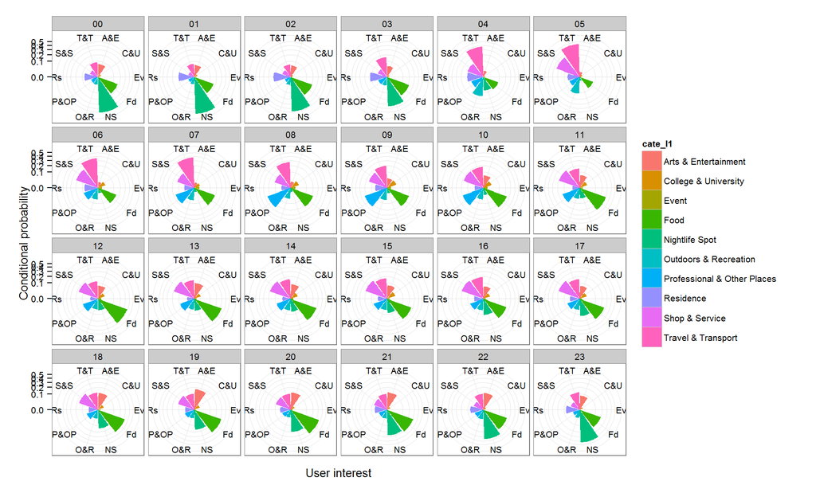

```r
# frequency statistics
cate.on.hour = xtabs2(data = exp.data, obs.col = "cate_l1",
                          cond.col = "hour",p.joint = T,p.cond=T)

theme_new<-theme_set(theme_bw(base_size = 10))
gg.cate.on.hour <- ggplot(cate.on.hour,
                          aes(x=abbreviate(cate_l1,2),y=p.cond,fill=cate_l1)) +
    geom_bar(stat="identity") +
    labs(x="User interest",y="Conditional probability")+
    facet_wrap(~condition,ncol=6,nrow=4)+
    scale_y_sqrt()+
    coord_polar()

gg.cate.on.hour
```

This fact can also be demonstrated from chi-square test:

```r
# frequency dataframe to contingency table
cate.on.hour.table = xtabs(Freq ~ condition+cate_l1, data=cate.on.hour)
chisq.test(cate.on.hour.table,simulate.p.value = T)
```

```
##
##  Pearson's Chi-squared test with simulated p-value (based on 2000
##  replicates)
##
## data:  cate.on.hour.table
## X-squared = 48572, df = NA, p-value = 0.0004998
```

##### 2.2. spatial influences

Similary, we reveal the spatial influences on user interest both with graphics and chi-square test.

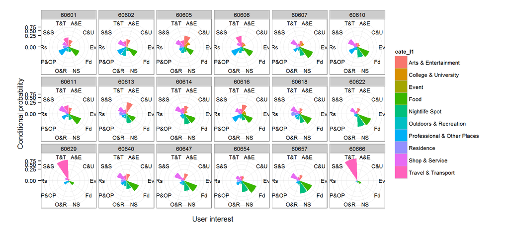

```r
# frequency statistics
cate.on.zip = xtabs2(data = exp.data, obs.col = "cate_l1",
                      cond.col = city.guide$spatial.attr[1],
                      p.joint = T,p.cond=T)


# for visualization purpose, we select only 18 most popular zip code regions (condition)
cate.on.zip.plot = cate.on.zip[which(cate.on.zip$condition %in%
    unique(cate.on.zip[order(cate.on.zip$marg.freq,decreasing=T),"condition"])[1:18]),]
theme_new<-theme_set(theme_bw(base_size = 10))
gg.cate.on.zip <- ggplot(cate.on.zip.plot,
                         aes(x=abbreviate(cate_l1,2),y=p.cond,fill=cate_l1)) +
    geom_bar(stat="identity") +
    labs(x="User interest",y="Conditional probability")+
    facet_wrap(~condition,ncol=6)+
    scale_y_sqrt()+
    coord_polar()
gg.cate.on.zip
```

```r
# frequency dataframe to contingency table
cate.on.zip.table = xtabs(Freq ~ condition+cate_l1, data=cate.on.zip)
chisq.test(cate.on.zip.table,simulate.p.value = T)
```

```
##
##  Pearson's Chi-squared test with simulated p-value (based on 2000
##  replicates)
##
## data:  cate.on.zip.table
## X-squared = 168827, df = NA, p-value = 0.0004998
```

##### 2.3. sequential influences

The sequential influences are a little bit tricky to see, because the fuzzy dataset from Foursquare would result into some problematic scenarios that must be excluede/considered:

- when a user kept checking in at the same place;
- when two check-ins are taken place not really “consequtively” (long time interval);
- other scenarios??

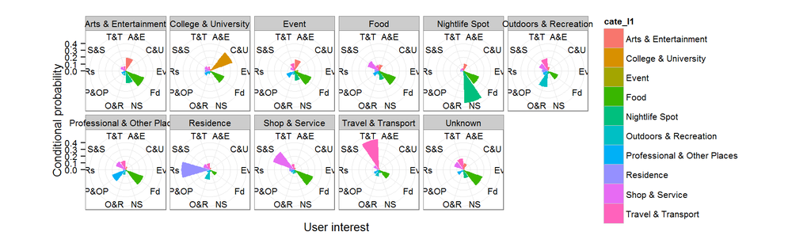

```r
# add weight based on time interval
exp.data$wgt = 2 ^ ( -1 * exp.data$time.interval + 1)

# remove continuous check-ins by the same user (by changing the weight to 0)
exp.data$wgt = with(exp.data,
                    ifelse(venue_id==last.venue_id, 0, wgt))

# deal with the empty values
exp.data$wgt = with(exp.data,
        ifelse(is.na(last.cate_l1)|time.interval>12,
               mean(wgt,na.rm=T),wgt))
exp.data$last.cate_l1 = with(exp.data,
        as.factor(ifelse(is.na(last.cate_l1)|time.interval>12,
            "Unknown",as.character(last.cate_l1))))
exp.data$last.cate_l2 = with(exp.data,
        as.factor(ifelse(is.na(last.cate_l2)|time.interval>12,
           "Unknown",as.character(last.cate_l2))))
exp.data$last.venue_id = with(exp.data,
        as.factor(ifelse(is.na(last.venue_id)|time.interval>12,
           "Unknown",as.character(last.venue_id))))

# weighted statistics for frequency/probability
cate.on.last = xtabs2(data = exp.data, obs.col = "cate_l1",
                      cond.col = "last.cate_l1", wgt.col= "wgt",
                      p.joint = T,p.cond=T,p.marg=T)

theme_new<-theme_set(theme_bw(base_size = 10))
gg.cate.on.zip <- ggplot(cate.on.last,
                         aes(x=abbreviate(cate_l1,2),y=p.cond,fill=cate_l1)) +
    geom_bar(stat="identity") +
    labs(x="User interest",y="Conditional probability")+
    facet_wrap(~condition,ncol=6)+
    coord_polar()
gg.cate.on.zip
```

```r
# frequency dataframe to contingency table
cate.on.last.table = xtabs(Freq ~ condition+cate_l1, data=cate.on.last)
chisq.test(cate.on.last.table,simulate.p.value = T)
```

```
##
##  Pearson's Chi-squared test with simulated p-value (based on 2000
##  replicates)
##
## data:  cate.on.last.table
## X-squared = 41574, df = NA, p-value = 0.0004998
```

##### 2.4. correlation / interaction

We assume there exist some correlations/interactions among these contextual factors.

- Correlation means the value of one context (e.g., last category) relies on another context (e.g., hour).
- Interaction means that the influence (magnitude, direction) of one context (e.g., last category) on the dependent variable (user interest) changes with another context (e.g., space).

#### 3. Dealing with high-cardinality categorical attributes

One of the shortcomings of regression (both linear and logistic) is that it doesnt handle categorical variables with a very large number of possible values (for example, postal codes). We can get around this, of course, by going to another modeling technique, such as Naive Bayes; however, we lose some of the advantages of regression — namely, the models explicit estimates of variables explanatory value, and explicit insight into and control of variable to variable dependence.

[D.Micci-Barreca,2001](http://dl.acm.org/citation.cfm?id=507538) provides an approach to deal with this problem. A similar approach is also mentioned [here](http://www.win-vector.com/blog/2012/07/modeling-trick-impact-coding-of-categorical-variables-with-many-levels/) The basic idea behind this is to transform categorical variables into continuous values with the *impact of each category value* on the outcome.

Here we first use spatial context (zip code) as an example.

```r
categorical.scaler.zip <- xtabs2(data = exp.data,
                                 obs.col = "cate_l2", cond.col = "ZIP",
                                 p.cond=T, p.prior=T)
categorical.scaler.zip$prob.est.zip = with(categorical.scaler.zip,
    marg.freq/(marg.freq+4)*p.cond + 4/(marg.freq+4)*p.prior)
# apply
checkin.continuous = merge(exp.data,
                           categorical.scaler.zip[,c(1,2,9)],
                           by.x=c("cate_l2","ZIP"),
                           by.y=c("cate_l2","condition"),
                           all.x=T)

# without impact model
t0=Sys.time()
glmodel1 <- glm(cate_l2 ~  ZIP ,
               data=checkin.continuous, family=binomial(link="logit"))
Sys.time()-t0
```

```
## Time difference of 1.269 mins
```

```r
summary(glmodel1)
```

```
##
## Call:
## glm(formula = cate_l2 ~ ZIP, family = binomial(link = "logit"),
##     data = checkin.continuous)
##
## Deviance Residuals:
##    Min      1Q  Median      3Q     Max
##  -3.66    0.00    0.00    0.00    0.05
##
## Coefficients:
##              Estimate Std. Error z value Pr(>|z|)
## (Intercept)  2.66e+01   4.47e+03    0.01        1
## ZIP60602    -3.12e-03   7.19e+03    0.00        1
## ZIP60603    -3.12e-03   8.22e+03    0.00        1
## ZIP60604    -3.11e-03   8.80e+03    0.00        1
## ZIP60605    -3.12e-03   6.28e+03    0.00        1
## ZIP60606    -3.12e-03   7.17e+03    0.00        1
## ZIP60607    -3.12e-03   6.12e+03    0.00        1
## ZIP60608    -3.12e-03   7.90e+03    0.00        1
## ZIP60609    -3.12e-03   1.15e+04    0.00        1
## ZIP60610    -3.12e-03   7.06e+03    0.00        1
## ZIP60611    -3.12e-03   5.35e+03    0.00        1
## ZIP60612    -3.12e-03   7.89e+03    0.00        1
## ZIP60613    -3.12e-03   6.42e+03    0.00        1
## ZIP60614    -3.12e-03   5.70e+03    0.00        1
## ZIP60615    -3.12e-03   9.32e+03    0.00        1
## ZIP60616    -3.12e-03   7.14e+03    0.00        1
## ZIP60617    -3.12e-03   1.33e+04    0.00        1
## ZIP60618    -3.12e-03   6.87e+03    0.00        1
## ZIP60619    -3.12e-03   1.43e+04    0.00        1
## ZIP60620    -3.12e-03   1.44e+04    0.00        1
## ZIP60621    -3.12e-03   2.42e+04    0.00        1
## ZIP60622    -3.12e-03   6.10e+03    0.00        1
## ZIP60623    -3.12e-03   1.59e+04    0.00        1
## ZIP60624    -3.12e-03   2.01e+04    0.00        1
## ZIP60625    -3.12e-03   8.68e+03    0.00        1
## ZIP60626    -3.12e-03   8.50e+03    0.00        1
## ZIP60628    -3.12e-03   1.59e+04    0.00        1
## ZIP60629    -3.12e-03   7.11e+03    0.00        1
## ZIP60630    -3.12e-03   8.34e+03    0.00        1
```

[output cut: 23 more lines]

```
## ZIP60657    -1.99e+01   4.47e+03    0.00        1
## ZIP60659    -3.12e-03   1.58e+04    0.00        1
## ZIP60660    -3.12e-03   8.92e+03    0.00        1
## ZIP60661    -3.12e-03   7.51e+03    0.00        1
## ZIP60666    -3.12e-03   5.42e+03    0.00        1
## ZIP60707    -3.12e-03   2.01e+04    0.00        1
## ZIP60827    -3.12e-03   8.65e+04    0.00        1
##
## (Dispersion parameter for binomial family taken to be 1)
##
##     Null deviance: 349.81  on 183836  degrees of freedom
## Residual deviance: 261.56  on 183778  degrees of freedom
## AIC: 379.6
##
## Number of Fisher Scoring iterations: 25
```

```r
1 - glmodel1$deviance/glmodel1$null.deviance
```

```
## [1] 0.2523
```

```r
# with impact moidel
t0=Sys.time()
glmodel2 <- glm(cate_l2 ~  prob.est.zip ,
               data=checkin.continuous, family=binomial(link="logit"))
Sys.time()-t0
```

```
## Time difference of 7.319 secs
```

```r
summary(glmodel2)
```

```
##
## Call:
## glm(formula = cate_l2 ~ prob.est.zip, family = binomial(link = "logit"),
##     data = checkin.continuous)
##
## Deviance Residuals:
##    Min      1Q  Median      3Q     Max
## -3.652   0.000   0.000   0.001   0.087
##
## Coefficients:
##              Estimate Std. Error z value Pr(>|z|)
## (Intercept)     5.518      0.369   14.95  < 2e-16 ***
## prob.est.zip  927.899    224.203    4.14  3.5e-05 ***
## ---
## Signif. codes:  0 '***' 0.001 '**' 0.01 '*' 0.05 '.' 0.1 ' ' 1
##
## (Dispersion parameter for binomial family taken to be 1)
##
##     Null deviance: 349.81  on 183836  degrees of freedom
## Residual deviance: 260.70  on 183835  degrees of freedom
## AIC: 264.7
##
## Number of Fisher Scoring iterations: 20
```

```r
1 - glmodel2$deviance/glmodel2$null.deviance
```

```
## [1] 0.2547
```

We now perform similar operations on the temporal context:

```r
# impact model for temporal context
categorical.scaler.hour <- xtabs2(data = exp.data,
                                 obs.col = "cate_l2", cond.col = "hour",
                                 p.cond=T, p.prior=T)
categorical.scaler.hour$prob.est.hour = with(categorical.scaler.hour,
    marg.freq/(marg.freq+4)*p.cond + 4/(marg.freq+4)*p.prior)
# apply
checkin.continuous = merge(checkin.continuous,
                           categorical.scaler.hour[,c(1,2,9)],
                           by.x=c("cate_l2","hour"),
                           by.y=c("cate_l2","condition"),
                           all.x=T)

# without impact model
t0=Sys.time()
glmodel3 <- glm(cate_l2 ~  hour ,
               data=checkin.continuous, family=binomial(link="logit"))
Sys.time()-t0
```

```
## Time difference of 22.25 secs
```

```r
summary(glmodel3)
```

```
##
## Call:
## glm(formula = cate_l2 ~ hour, family = binomial(link = "logit"),
##     data = checkin.continuous)
##
## Deviance Residuals:
##    Min      1Q  Median      3Q     Max
## -4.399   0.000   0.011   0.020   0.028
##
## Coefficients:
##              Estimate Std. Error z value Pr(>|z|)
## (Intercept)  2.56e+01   3.63e+03    0.01     0.99
## hour01      -6.57e-03   6.04e+03    0.00     1.00
## hour02      -6.57e-03   7.08e+03    0.00     1.00
## hour03      -6.57e-03   8.92e+03    0.00     1.00
## hour04      -6.57e-03   8.25e+03    0.00     1.00
## hour05      -6.57e-03   6.19e+03    0.00     1.00
## hour06      -6.57e-03   5.42e+03    0.00     1.00
## hour07      -6.57e-03   4.82e+03    0.00     1.00
## hour08      -6.57e-03   4.37e+03    0.00     1.00
## hour09      -6.57e-03   4.36e+03    0.00     1.00
## hour10      -6.57e-03   4.39e+03    0.00     1.00
## hour11      -6.57e-03   4.24e+03    0.00     1.00
## hour12      -6.57e-03   4.12e+03    0.00     1.00
## hour13      -6.57e-03   4.15e+03    0.00     1.00
## hour14      -1.70e+01   3.63e+03    0.00     1.00
## hour15      -1.64e+01   3.63e+03    0.00     1.00
## hour16      -1.70e+01   3.63e+03    0.00     1.00
## hour17      -1.61e+01   3.63e+03    0.00     1.00
## hour18      -1.59e+01   3.63e+03    0.00     1.00
## hour19      -1.75e+01   3.63e+03    0.00     1.00
## hour20      -1.73e+01   3.63e+03    0.00     1.00
## hour21      -6.57e-03   4.28e+03    0.00     1.00
## hour22      -6.57e-03   4.44e+03    0.00     1.00
## hour23      -1.77e+01   3.63e+03    0.00     1.00
##
## (Dispersion parameter for binomial family taken to be 1)
##
##     Null deviance: 349.81  on 183836  degrees of freedom
## Residual deviance: 321.00  on 183813  degrees of freedom
## AIC: 369
##
## Number of Fisher Scoring iterations: 24
```

```r
1 - glmodel3$deviance/glmodel3$null.deviance
```

```
## [1] 0.08235
```

```r
# with impact model
t0=Sys.time()
glmodel4 <- glm(cate_l2 ~  prob.est.hour ,
               data=checkin.continuous, family=binomial(link="logit"))
Sys.time()-t0
```

```
## Time difference of 7.761 secs
```

```r
summary(glmodel4)
```

```
##
## Call:
## glm(formula = cate_l2 ~ prob.est.hour, family = binomial(link = "logit"),
##     data = checkin.continuous)
##
## Deviance Residuals:
##    Min      1Q  Median      3Q     Max
## -3.556   0.000   0.000   0.000   0.171
##
## Coefficients:
##               Estimate Std. Error z value Pr(>|z|)
## (Intercept)       3.83       0.42    9.13  < 2e-16 ***
## prob.est.hour  6297.64    1412.68    4.46  8.3e-06 ***
## ---
## Signif. codes:  0 '***' 0.001 '**' 0.01 '*' 0.05 '.' 0.1 ' ' 1
##
## (Dispersion parameter for binomial family taken to be 1)
##
##     Null deviance: 349.81  on 183836  degrees of freedom
## Residual deviance: 215.98  on 183835  degrees of freedom
## AIC: 220
##
## Number of Fisher Scoring iterations: 21
```

```r
1 - glmodel4$deviance/glmodel4$null.deviance
```

```
## [1] 0.3826
```

And the conclusions for spatial context hold true also for temporal one (more efficient, more significant). More interestingly, the model after transformation provides much better describtion of the data: from merely 8% to 38%.

Then how about if we consider both?

```r
# adding impact model for both space and time
glmodel5 <- glm(cate_l2 ~  prob.est.hour + prob.est.zip ,
               data=checkin.continuous, family=binomial(link="logit"))
summary(glmodel5)
```

```
##
## Call:
## glm(formula = cate_l2 ~ prob.est.hour + prob.est.zip, family = binomial(link = "logit"),
##     data = checkin.continuous)
##
## Deviance Residuals:
##    Min      1Q  Median      3Q     Max
## -3.411   0.000   0.000   0.000   0.232
##
## Coefficients:
##               Estimate Std. Error z value Pr(>|z|)
## (Intercept)      3.242      0.444    7.31  2.8e-13 ***
## prob.est.hour 5241.001   1378.279    3.80  0.00014 ***
## prob.est.zip   402.392    185.360    2.17  0.02994 *
## ---
## Signif. codes:  0 '***' 0.001 '**' 0.01 '*' 0.05 '.' 0.1 ' ' 1
##
## (Dispersion parameter for binomial family taken to be 1)
##
##     Null deviance: 349.81  on 183836  degrees of freedom
## Residual deviance: 204.34  on 183834  degrees of freedom
## AIC: 210.3
##
## Number of Fisher Scoring iterations: 21
```

```r
1 - glmodel5$deviance/glmodel5$null.deviance
```

```
## [1] 0.4159
```

The model can describe 41.6% variances in the dependent variable (i.e. user interest).

Furthermore, we want to investigate the *correlation/interaction* between the two predictors before/after applying the impact model.

```r
# correlations ?
cor(checkin.continuous$prob.est.hour, checkin.continuous$prob.est.zip)
```

```
## [1] 0.5808
```

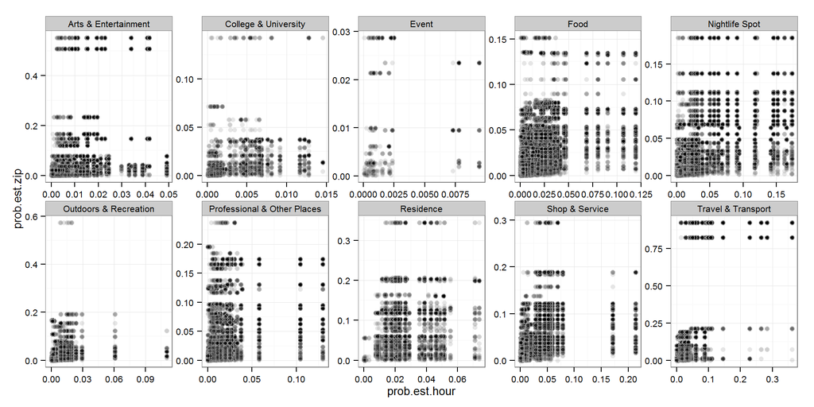

```r
ggplot(checkin.continuous,aes(x=prob.est.hour,y=prob.est.zip))+
    geom_point(alpha=0.1,shape=21,fill="black",color="white")+
    facet_wrap(~cate_l1,ncol = 5,scale="free")+
    theme_bw(base_size = 10)
```

```r
# interactions between time and space
glmodel6 <- glm(cate_l2 ~  prob.est.hour * prob.est.zip ,
               data=checkin.continuous, family=binomial(link="logit"))
summary(glmodel6)
```

```
##
## Call:
## glm(formula = cate_l2 ~ prob.est.hour * prob.est.zip, family = binomial(link = "logit"),
##     data = checkin.continuous)
##
## Deviance Residuals:
##    Min      1Q  Median      3Q     Max
## -3.402   0.000   0.000   0.000   0.215
##
## Coefficients:
##                            Estimate Std. Error z value Pr(>|z|)
## (Intercept)                3.47e+00   5.44e-01    6.37  1.9e-10 ***
## prob.est.hour              4.26e+03   1.88e+03    2.26    0.024 *
## prob.est.zip               2.25e+02   2.95e+02    0.76    0.446
## prob.est.hour:prob.est.zip 7.22e+05   1.03e+06    0.70    0.483
## ---
## Signif. codes:  0 '***' 0.001 '**' 0.01 '*' 0.05 '.' 0.1 ' ' 1
##
## (Dispersion parameter for binomial family taken to be 1)
##
##     Null deviance: 349.81  on 183836  degrees of freedom
## Residual deviance: 203.84  on 183833  degrees of freedom
## AIC: 211.8
##
## Number of Fisher Scoring iterations: 25
```

```r
1 - glmodel6$deviance/glmodel6$null.deviance
```

```
## [1] 0.4173
```

```r
1 - glmodel6$deviance/glmodel5$deviance
```

```
## [1] 0.00244
```

Similarly, the impact model is applied on the sequential context:

```r
categorical.scaler.last <- xtabs2(data = exp.data,
                                 obs.col = "cate_l2", cond.col = "last.cate_l2",
                                 wgt.col = "wgt",
                                 p.cond=T, p.prior=T)
categorical.scaler.last$prob.est.last = with(categorical.scaler.last,
    marg.freq/(marg.freq+4)*p.cond + 4/(marg.freq+4)*p.prior)
# apply
checkin.continuous = merge(checkin.continuous,
                           categorical.scaler.last[,c(1,2,9)],
                           by.x=c("cate_l2","last.cate_l2"),
                           by.y=c("cate_l2","condition"),
                           all.x=T)
```

** dealing with weights**

The impact model of sequential context has taken *time interval* into consideration (considering the interval as weight: the smaller the time interval is, (the more precise we tend to know about the sequential context), the heavier impact the previous record would have on the user interest).

However, the classic (non-)linear regression models normally consider all the information as equally precise. In other words, the standard deviation of the error term is constant over all values of the predictor or explanatory variables. Unfortunatelly, the sequential context does not follow this premise. In situations like this, when it may not be reasonable to assume that every observation should be treated equally, weighted least squares can often be used to maximize the efficiency of parameter estimation.

This is done by attempting to give each data point its proper amount of influence over the parameter estimates. A procedure that treats all of the data equally would give less precisely measured points more influence than they should have and would give highly precise points too little influence.

This technique is actually frequently used in spatial analysis (spatial weighted regression). We will apply similar techniques to the seqential context in our study case.

```r
glmodel7 <- glm(cate_l2 ~  prob.est.last, weights=wgt,
               data=checkin.continuous, family=binomial(link="logit"))
summary(glmodel7)
```

```
##
## Call:
## glm(formula = cate_l2 ~ prob.est.last, family = binomial(link = "logit"),
##     data = checkin.continuous, weights = wgt)
##
## Deviance Residuals:
##    Min      1Q  Median      3Q     Max
## -6.113   0.008   0.008   0.008   0.020
##
## Coefficients:
##               Estimate Std. Error z value Pr(>|z|)
## (Intercept)      9.257      0.394   23.52   <2e-16 ***
## prob.est.last    0.947      3.754    0.25      0.8
## ---
## Signif. codes:  0 '***' 0.001 '**' 0.01 '*' 0.05 '.' 0.1 ' ' 1
##
## (Dispersion parameter for binomial family taken to be 1)
##
##     Null deviance: 178.27  on 182463  degrees of freedom
## Residual deviance: 178.20  on 182462  degrees of freedom
## AIC: 88.9
##
## Number of Fisher Scoring iterations: 12
```

```r
1 - glmodel7$deviance/glmodel7$null.deviance
```

```
## [1] 0.0003979
```

… How come….??